# Trabalho Final — Gestão e Análise de Dados (GETI)

**Dataset:** `vehicle_price_prediction.csv` — 1.000.000 de veículos do mercado dos EUA (Kaggle). **Alvo de estudo:** `price` (preço do usado, em USD).

Este notebook cumpre as tarefas do descritivo (ver `Descritivo-do-Trabalho.md`):

1. **5.1 Pré-processamento** — *missing values*, tratamento, codificação de categóricos e normalização.
2. **5.2.1 Regressão Linear Múltipla** — coeficientes, R² e valor-P por feature.
3. **5.2.2 K-means** — agrupamento dos veículos e análise de um grupo.
4. **5.2.3 K-NN** — os 5 veículos mais parecidos com um escolhido e checagem do cluster.

> **Observação de execução:** por padrão `USE_SAMPLE = False`, ou seja, **todas as etapas rodam sobre o dataset completo (1M de linhas)**. Métricas O(n²) (silhouette) e os gráficos de dispersão usam uma subamostra apenas para cálculo/plotagem; os modelos são treinados no dataset inteiro.

## 0. Configuração e carga dos dados

```python
import numpy as np
import pandas as pd
import matplotlib.pyplot as plt
import seaborn as sns

from sklearn.impute import SimpleImputer
from sklearn.preprocessing import OrdinalEncoder, StandardScaler
from sklearn.cluster import MiniBatchKMeans, KMeans
from sklearn.neighbors import NearestNeighbors
from sklearn.decomposition import PCA
from sklearn.metrics import silhouette_score

import statsmodels.api as sm

# --- Parâmetros globais ---
RANDOM_STATE = 42
USE_SAMPLE = False        # False = dataset completo (1M). True = amostra rápida p/ exploração.
SAMPLE_SIZE = 150_000     # usado somente quando USE_SAMPLE = True
CSV_PATH = "vehicle_price_prediction.csv"

sns.set_theme(style="whitegrid")
pd.set_option("display.max_columns", None)
pd.set_option("display.width", 140)
np.random.seed(RANDOM_STATE)
print("Configuração carregada. USE_SAMPLE =", USE_SAMPLE)
```

```
Matplotlib is building the font cache; this may take a moment.
```

```
Configuração carregada. USE_SAMPLE = False
```

```python
# IMPORTANTE: a coluna accident_history usa "None" como CATEGORIA legítima
# (= "sem histórico de acidentes"). O pandas, por padrão, interpretaria a string
# "None" como valor ausente (NaN). Por isso lemos com keep_default_na=False e
# tratamos apenas campos realmente vazios como ausentes.
df = pd.read_csv(CSV_PATH, keep_default_na=False, na_values=["", " "])
print("Dimensões do dataset:", df.shape)
df.head()
```

```
Dimensões do dataset: (1000000, 20)
```

|  | make | model | year | mileage | engine_hp | transmission | fuel_type | drivetrain | body_type | exterior_color | interior_color | owner_count | accident_history | seller_type | condition | trim | vehicle_age | mileage_per_year | brand_popularity | price |
| --- | --- | --- | --- | --- | --- | --- | --- | --- | --- | --- | --- | --- | --- | --- | --- | --- | --- | --- | --- | --- |
| 0 | Volkswagen | Jetta | 2016 | 183903 | 173 | Manual | Electric | RWD | Sedan | Blue | Brown | 5 | None | Dealer | Excellent | EX | 9 | 20433.666667 | 0.040054 | 7208.52 |
| 1 | Lexus | RX | 2010 | 236643 | 352 | Manual | Gasoline | FWD | Sedan | Silver | Beige | 5 | Minor | Dealer | Good | LX | 15 | 15776.200000 | 0.039921 | 6911.81 |
| 2 | Subaru | Crosstrek | 2016 | 103199 | 188 | Automatic | Diesel | AWD | Sedan | Silver | Beige | 5 | None | Dealer | Excellent | Touring | 9 | 11466.555556 | 0.040230 | 11915.63 |
| 3 | Cadillac | Lyriq | 2016 | 118889 | 338 | Manual | Gasoline | AWD | SUV | Black | Gray | 3 | None | Private | Good | Base | 9 | 13209.888889 | 0.039847 | 25984.79 |
| 4 | Toyota | Highlander | 2018 | 204170 | 196 | Manual | Diesel | FWD | Sedan | Red | Brown | 5 | Minor | Dealer | Excellent | Sport | 7 | 29167.142857 | 0.039627 | 8151.30 |

```python
df.info()
```

```
<class 'pandas.DataFrame'>
RangeIndex: 1000000 entries, 0 to 999999
Data columns (total 20 columns):
 #   Column            Non-Null Count    Dtype
---  ------            --------------    -----
 0   make              1000000 non-null  str
 1   model             1000000 non-null  str
 2   year              1000000 non-null  int64
 3   mileage           1000000 non-null  int64
 4   engine_hp         1000000 non-null  int64
 5   transmission      1000000 non-null  str
 6   fuel_type         1000000 non-null  str
 7   drivetrain        1000000 non-null  str
 8   body_type         1000000 non-null  str
 9   exterior_color    1000000 non-null  str
 10  interior_color    1000000 non-null  str
 11  owner_count       1000000 non-null  int64
 12  accident_history  1000000 non-null  str
 13  seller_type       1000000 non-null  str
 14  condition         1000000 non-null  str
 15  trim              1000000 non-null  str
 16  vehicle_age       1000000 non-null  int64
 17  mileage_per_year  1000000 non-null  float64
 18  brand_popularity  1000000 non-null  float64
 19  price             1000000 non-null  float64
dtypes: float64(3), int64(5), str(12)
memory usage: 152.6 MB
```

```python
df.describe(include="all").T
```

|  | count | unique | top | freq | mean | std | min | 25% | 50% | 75% | max |
| --- | --- | --- | --- | --- | --- | --- | --- | --- | --- | --- | --- |
| make | 1000000 | 25 | Kia | 40484 | NaN | NaN | NaN | NaN | NaN | NaN | NaN |
| model | 1000000 | 105 | 300 | 20202 | NaN | NaN | NaN | NaN | NaN | NaN | NaN |
| year | 1000000.0 | NaN | NaN | NaN | 2017.453816 | 3.902285 | 2000.0 | 2015.0 | 2018.0 | 2020.0 | 2025.0 |
| mileage | 1000000.0 | NaN | NaN | NaN | 112660.126464 | 72088.236925 | 500.0 | 57654.0 | 103331.0 | 157865.0 | 300000.0 |
| engine_hp | 1000000.0 | NaN | NaN | NaN | 235.664301 | 93.614773 | 90.0 | 162.0 | 215.0 | 300.0 | 581.0 |
| transmission | 1000000 | 2 | Automatic | 500263 | NaN | NaN | NaN | NaN | NaN | NaN | NaN |
| fuel_type | 1000000 | 3 | Electric | 359597 | NaN | NaN | NaN | NaN | NaN | NaN | NaN |
| drivetrain | 1000000 | 3 | AWD | 361110 | NaN | NaN | NaN | NaN | NaN | NaN | NaN |
| body_type | 1000000 | 7 | SUV | 406693 | NaN | NaN | NaN | NaN | NaN | NaN | NaN |
| exterior_color | 1000000 | 6 | White | 166934 | NaN | NaN | NaN | NaN | NaN | NaN | NaN |
| interior_color | 1000000 | 4 | Beige | 250570 | NaN | NaN | NaN | NaN | NaN | NaN | NaN |
| owner_count | 1000000.0 | NaN | NaN | NaN | 3.477846 | 1.544856 | 1.0 | 2.0 | 4.0 | 5.0 | 5.0 |
| accident_history | 1000000 | 3 | None | 750133 | NaN | NaN | NaN | NaN | NaN | NaN | NaN |
| seller_type | 1000000 | 2 | Dealer | 699710 | NaN | NaN | NaN | NaN | NaN | NaN | NaN |
| condition | 1000000 | 3 | Good | 499683 | NaN | NaN | NaN | NaN | NaN | NaN | NaN |
| trim | 1000000 | 6 | Limited | 167294 | NaN | NaN | NaN | NaN | NaN | NaN | NaN |
| vehicle_age | 1000000.0 | NaN | NaN | NaN | 7.585987 | 3.829534 | 1.0 | 5.0 | 7.0 | 10.0 | 25.0 |
| mileage_per_year | 1000000.0 | NaN | NaN | NaN | 14540.6742 | 6108.901522 | 33.333333 | 10487.633523 | 14688.118056 | 18685.942308 | 55391.0 |
| brand_popularity | 1000000.0 | NaN | NaN | NaN | 0.040001 | 0.000234 | 0.039318 | 0.039842 | 0.040022 | 0.040148 | 0.040484 |
| price | 1000000.0 | NaN | NaN | NaN | 20329.302593 | 13644.467189 | 1500.0 | 10324.5275 | 17864.74 | 27601.4025 | 93422.09 |

### Seleção do conjunto de trabalho (`df_work`)

Ponto **único** de troca entre dataset completo e amostra. Como `USE_SAMPLE = False`, `df_work` é o dataset inteiro. Para uma exploração interativa mais rápida, basta mudar `USE_SAMPLE = True` no topo e reexecutar.

```python
if USE_SAMPLE:
    df_work = df.sample(n=SAMPLE_SIZE, random_state=RANDOM_STATE).reset_index(drop=True)
else:
    df_work = df.reset_index(drop=True)

print("df_work:", df_work.shape, "| modo:", "AMOSTRA" if USE_SAMPLE else "COMPLETO")
```

```
df_work: (1000000, 20) | modo: COMPLETO
```

## 1. Pré-processamento (Tarefa 5.1)

Definimos os papéis de cada atributo:

- **Numéricos:** `year`, `mileage`, `engine_hp`, `owner_count`, `vehicle_age`, `mileage_per_year`, `brand_popularity`.
- **Categóricos ordinais:** `condition` (Fair < Good < Excellent), `accident_history` (None < Minor < Major).
- **Categóricos nominais (baixa cardinalidade):** `transmission`, `fuel_type`, `drivetrain`, `body_type`, `seller_type`, `exterior_color`, `interior_color`, `trim`.
- **Categóricos nominais (alta cardinalidade):** `make` (25), `model` (105).
- **Alvo:** `price`.

```python
NUMERIC_COLS = ["year", "mileage", "engine_hp", "owner_count",
                "vehicle_age", "mileage_per_year", "brand_popularity"]
ORDINAL_COLS = ["condition", "accident_history"]
NOMINAL_LOW  = ["transmission", "fuel_type", "drivetrain", "body_type",
                "seller_type", "exterior_color", "interior_color", "trim"]
NOMINAL_HIGH = ["make", "model"]
TARGET = "price"

ORDINAL_CATEGORIES = {
    "condition": ["Fair", "Good", "Excellent"],          # pior -> melhor
    "accident_history": ["None", "Minor", "Major"],       # menos -> mais grave
}
```

### 1.1 Identificação de *missing values*

```python
na_counts = df.isna().sum()
na_table = pd.DataFrame({
    "n_missing": na_counts,
    "pct_missing": (na_counts / len(df) * 100).round(4),
})
print("Total de valores ausentes no dataset:", int(na_counts.sum()))
na_table
```

```
Total de valores ausentes no dataset: 0
```

|  | n_missing | pct_missing |
| --- | --- | --- |
| make | 0 | 0.0 |
| model | 0 | 0.0 |
| year | 0 | 0.0 |
| mileage | 0 | 0.0 |
| engine_hp | 0 | 0.0 |
| transmission | 0 | 0.0 |
| fuel_type | 0 | 0.0 |
| drivetrain | 0 | 0.0 |
| body_type | 0 | 0.0 |
| exterior_color | 0 | 0.0 |
| interior_color | 0 | 0.0 |
| owner_count | 0 | 0.0 |
| accident_history | 0 | 0.0 |
| seller_type | 0 | 0.0 |
| condition | 0 | 0.0 |
| trim | 0 | 0.0 |
| vehicle_age | 0 | 0.0 |
| mileage_per_year | 0 | 0.0 |
| brand_popularity | 0 | 0.0 |
| price | 0 | 0.0 |

[figure not shown]

```python
fig, ax = plt.subplots(figsize=(10, 4))
na_table["n_missing"].plot(kind="bar", ax=ax, color="#4C72B0")
ax.set_title("Valores ausentes por coluna")
ax.set_ylabel("nº de NaN")
ax.set_ylim(0, max(1, na_table["n_missing"].max()))
plt.xticks(rotation=45, ha="right")
plt.tight_layout()
plt.show()
```

**Resultado:** o dataset **não possui valores ausentes** — todas as 20 colunas têm 0 *missing values*.

Como não há ausentes reais, não é necessária imputação. Ainda assim, demonstramos a seguir a **técnica** que seria aplicada caso houvesse dados faltantes.

### 1.2 Técnica de tratamento de dados faltantes (demonstração)

Técnica escolhida — **imputação simples** com `sklearn.impute.SimpleImputer`:

- **Numéricos → mediana:** robusta a *outliers* (mais que a média) e não distorce a escala.
- **Categóricos → moda** (valor mais frequente): preserva a distribuição da categoria dominante.

Para demonstrar, criamos uma cópia de 1.000 linhas e **injetamos NaN artificialmente** (apenas para fins didáticos — o dataset original continua intacto).

```python
demo = df.head(1000).copy()

# Injeta NaN artificialmente em uma coluna numérica e uma categórica.
rng = np.random.default_rng(RANDOM_STATE)
demo.loc[rng.choice(demo.index, 50, replace=False), "engine_hp"] = np.nan
demo.loc[rng.choice(demo.index, 50, replace=False), "fuel_type"] = np.nan

print("NaN injetados -> engine_hp:", int(demo['engine_hp'].isna().sum()),
      "| fuel_type:", int(demo['fuel_type'].isna().sum()))

num_imputer = SimpleImputer(strategy="median")
cat_imputer = SimpleImputer(strategy="most_frequent")

demo["engine_hp"] = num_imputer.fit_transform(demo[["engine_hp"]])
demo["fuel_type"] = cat_imputer.fit_transform(demo[["fuel_type"]]).ravel()

print("Após imputação -> engine_hp:", int(demo['engine_hp'].isna().sum()),
      "| fuel_type:", int(demo['fuel_type'].isna().sum()))
print("Mediana usada (engine_hp):", float(num_imputer.statistics_[0]))
print("Moda usada (fuel_type):", cat_imputer.statistics_[0])
```

```
NaN injetados -> engine_hp: 50 | fuel_type: 50
Após imputação -> engine_hp: 0 | fuel_type: 0
Mediana usada (engine_hp): 214.5
Moda usada (fuel_type): Diesel
```

### 1.3 Transformação de atributos categóricos em numéricos

Usamos três técnicas, escolhidas conforme a natureza de cada variável:

| Técnica | Aplicada a | Por quê |
| --- | --- | --- |
| **Ordinal Encoding** | `condition`, `accident_history` | Há ordem natural; preservá-la dá informação ao modelo. |
| **One-Hot Encoding** | nominais de baixa cardinalidade | Sem ordem; one-hot evita criar uma ordem falsa. Poucas categorias → poucas colunas novas. |
| **Frequency Encoding** | `make` (25), `model` (105) | Alta cardinalidade; one-hot explodiria em dezenas/centenas de colunas. A frequência é um sinal numérico compacto. |

`make` também é parcialmente redundante com `brand_popularity` (que já é uma codificação de popularidade da marca).

```python
proc = df_work.copy()

# (a) Ordinais -> inteiros respeitando a ordem definida.
ord_enc = OrdinalEncoder(categories=[ORDINAL_CATEGORIES[c] for c in ORDINAL_COLS])
proc[ORDINAL_COLS] = ord_enc.fit_transform(proc[ORDINAL_COLS])
print("Ordinais codificados:")
for c in ORDINAL_COLS:
    print(f"  {c}: {dict(zip(ORDINAL_CATEGORIES[c], range(len(ORDINAL_CATEGORIES[c]))))}")

# (b) Frequency encoding p/ alta cardinalidade.
for c in NOMINAL_HIGH:
    freq = proc[c].value_counts(normalize=True)
    proc[c + "_freq"] = proc[c].map(freq).astype(float)
proc = proc.drop(columns=NOMINAL_HIGH)

# (c) One-Hot p/ nominais de baixa cardinalidade (cast p/ int — pandas 3 gera bool).
proc = pd.get_dummies(proc, columns=NOMINAL_LOW, drop_first=True, dtype=int)

print("\nDimensões após codificação:", proc.shape)
proc.head()
```

```
Ordinais codificados:
  condition: {'Fair': 0, 'Good': 1, 'Excellent': 2}
  accident_history: {'None': 0, 'Minor': 1, 'Major': 2}
```

```
Dimensões após codificação: (1000000, 37)
```

|  | year | mileage | engine_hp | owner_count | accident_history | condition | vehicle_age | mileage_per_year | brand_popularity | price | make_freq | model_freq | transmission_Manual | fuel_type_Electric | fuel_type_Gasoline | drivetrain_FWD | drivetrain_RWD | body_type_Hatchback | body_type_Minivan | body_type_Pickup Truck | body_type_SUV | body_type_Sedan | body_type_Wagon | seller_type_Private | exterior_color_Blue | exterior_color_Gray | exterior_color_Red | exterior_color_Silver | exterior_color_White | … |
| --- | --- | --- | --- | --- | --- | --- | --- | --- | --- | --- | --- | --- | --- | --- | --- | --- | --- | --- | --- | --- | --- | --- | --- | --- | --- | --- | --- | --- | --- | --- |
| 0 | 2016 | 183903 | 173 | 5 | 0.0 | 2.0 | 9 | 20433.666667 | 0.040054 | 7208.52 | 0.040054 | 0.007931 | 1 | 1 | 0 | 0 | 1 | 0 | 0 | 0 | 0 | 1 | 0 | 0 | 1 | 0 | 0 | 0 | 0 | … |
| 1 | 2010 | 236643 | 352 | 5 | 1.0 | 1.0 | 15 | 15776.200000 | 0.039921 | 6911.81 | 0.039921 | 0.008065 | 1 | 0 | 1 | 1 | 0 | 0 | 0 | 0 | 0 | 1 | 0 | 0 | 0 | 0 | 0 | 1 | 0 | … |
| 2 | 2016 | 103199 | 188 | 5 | 0.0 | 2.0 | 9 | 11466.555556 | 0.040230 | 11915.63 | 0.040230 | 0.010147 | 0 | 0 | 0 | 0 | 0 | 0 | 0 | 0 | 0 | 1 | 0 | 0 | 0 | 0 | 0 | 1 | 0 | … |
| 3 | 2016 | 118889 | 338 | 3 | 0.0 | 1.0 | 9 | 13209.888889 | 0.039847 | 25984.79 | 0.039847 | 0.010055 | 1 | 0 | 1 | 0 | 0 | 0 | 0 | 0 | 1 | 0 | 0 | 1 | 0 | 0 | 0 | 0 | 0 | … |
| 4 | 2018 | 204170 | 196 | 5 | 1.0 | 2.0 | 7 | 29167.142857 | 0.039627 | 8151.30 | 0.039627 | 0.007943 | 1 | 0 | 0 | 1 | 0 | 0 | 0 | 0 | 0 | 1 | 0 | 0 | 0 | 0 | 1 | 0 | 0 | … |

### 1.4 Normalização

Aplicamos **padronização z-score** (`StandardScaler`): cada feature passa a ter média 0 e desvio 1. É essencial para algoritmos baseados em distância (K-means, K-NN) e torna os coeficientes da regressão comparáveis entre si. (Alternativa comum: `MinMaxScaler`, que reescala para [0, 1].)

A matriz padronizada `X_scaled` (todas as features, **exceto** o alvo `price`) é reutilizada nas três tarefas seguintes. O `price` é mantido à parte como `y`.

```python
feature_cols = [c for c in proc.columns if c != TARGET]
X = proc[feature_cols].astype(float)
y = proc[TARGET].astype(float)

scaler = StandardScaler()
X_scaled = pd.DataFrame(scaler.fit_transform(X), columns=feature_cols, index=proc.index)

print("X_scaled:", X_scaled.shape, "| nº de features:", len(feature_cols))
X_scaled.describe().T[["mean", "std", "min", "max"]].round(3).head(10)
```

```
X_scaled: (1000000, 36) | nº de features: 36
```

|  | mean | std | min | max |
| --- | --- | --- | --- | --- |
| year | 0.0 | 1.0 | -4.473 | 1.934 |
| mileage | -0.0 | 1.0 | -1.556 | 2.599 |
| engine_hp | 0.0 | 1.0 | -1.556 | 3.689 |
| owner_count | 0.0 | 1.0 | -1.604 | 0.985 |
| accident_history | -0.0 | 1.0 | -0.539 | 3.055 |
| condition | -0.0 | 1.0 | -2.031 | 1.092 |
| vehicle_age | -0.0 | 1.0 | -1.720 | 4.547 |
| mileage_per_year | 0.0 | 1.0 | -2.375 | 6.687 |
| brand_popularity | -0.0 | 1.0 | -2.922 | 2.064 |
| make_freq | -0.0 | 1.0 | -2.922 | 2.064 |

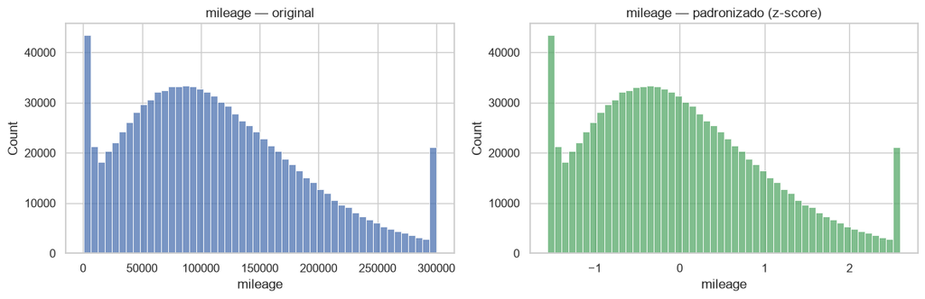

```python
# Evidência visual: distribuição de 'mileage' antes e depois da padronização.
fig, axes = plt.subplots(1, 2, figsize=(12, 4))
sns.histplot(X["mileage"], bins=50, ax=axes[0], color="#4C72B0")
axes[0].set_title("mileage — original")
sns.histplot(X_scaled["mileage"], bins=50, ax=axes[1], color="#55A868")
axes[1].set_title("mileage — padronizado (z-score)")
plt.tight_layout()
plt.show()
```

## 2. Regressão Linear Múltipla (Tarefa 5.2.1)

Objetivo: medir o **grau de importância de cada feature** na formação do `price`.

- **Variável dependente:** `price`.
- **Variáveis independentes:** todas as features padronizadas de `X_scaled`.
- **Cuidado com colinearidade:** `vehicle_age = AnoAtual − year`, portanto `year` e `vehicle_age` são perfeitamente colineares. **Removemos `year`** e mantemos `vehicle_age`.
- Usamos `statsmodels.OLS` (com constante) porque fornece **coeficientes, R², R²-ajustado e valor-P** por feature. Como `X_scaled` está padronizado, os coeficientes são *betas padronizados* e podem ser comparados diretamente em magnitude.

```python
X_reg = X_scaled.drop(columns=["year"])     # evita colinearidade com vehicle_age
X_reg = sm.add_constant(X_reg)

ols = sm.OLS(y, X_reg).fit()
print(ols.summary())
```

```
                            OLS Regression Results
==============================================================================
Dep. Variable:                  price   R-squared:                       0.908
Model:                            OLS   Adj. R-squared:                  0.908
Method:                 Least Squares   F-statistic:                 2.898e+05
Date:                Sat, 27 Jun 2026   Prob (F-statistic):               0.00
Time:                        22:24:46   Log-Likelihood:            -9.7478e+06
No. Observations:             1000000   AIC:                         1.950e+07
Df Residuals:                  999965   BIC:                         1.950e+07
Df Model:                          34
Covariance Type:            nonrobust
==========================================================================================
                             coef    std err          t      P>|t|      [0.025      0.975]
------------------------------------------------------------------------------------------
const                   2.033e+04      4.142   4908.276      0.000    2.03e+04    2.03e+04
mileage                -2534.0442     12.547   -201.957      0.000   -2558.637   -2509.452
engine_hp               8783.4177      4.480   1960.577      0.000    8774.637    8792.198
owner_count             -436.2159      5.433    -80.289      0.000    -446.864    -425.567
accident_history       -1319.8165      4.142   -318.649      0.000   -1327.935   -1311.698
condition                855.8173      4.142    206.624      0.000     847.699     863.935
vehicle_age            -6704.2690     10.741   -624.149      0.000   -6725.322   -6683.216
mileage_per_year        -708.9178      7.845    -90.363      0.000    -724.294    -693.541
brand_popularity          40.5717      2.125     19.096      0.000      36.408      44.736
make_freq                 40.5717      2.125     19.096      0.000      36.408      44.736
model_freq               185.6599      4.630     40.098      0.000     176.585     194.735
transmission_Manual        0.3143      4.142      0.076      0.940      -7.804       8.432
fuel_type_Electric        62.2608      4.844     12.854      0.000      52.768      71.754
fuel_type_Gasoline        -2.0717      4.829     -0.429      0.668     -11.536       7.392
drivetrain_FWD            34.7161      4.703      7.382      0.000      25.499      43.933
drivetrain_RWD            41.1140      4.703      8.742      0.000      31.897      50.331
body_type_Hatchback     -204.2918      4.818    -42.401      0.000    -213.735    -194.849
body_type_Minivan       -247.0209      5.252    -47.030      0.000    -257.315    -236.726
body_type_Pickup Truck  -289.0082      6.039    -47.858      0.000    -300.844    -277.172
body_type_SUV           -159.9750      7.690    -20.803      0.000    -175.047    -144.903
body_type_Sedan         -235.3374      7.554    -31.152      0.000    -250.144    -220.531
body_type_Wagon           21.3390      4.432      4.815      0.000      12.653      30.025
seller_type_Private     -449.3019      4.142   -108.477      0.000    -457.420    -441.184
exterior_color_Blue       -0.8962      5.351     -0.167      0.867     -11.384       9.591
exterior_color_Gray        6.5212      5.351      1.219      0.223      -3.967      17.009
exterior_color_Red         1.0729      5.352      0.200      0.841      -9.416      11.562
exterior_color_Silver     -1.9969      5.352     -0.373      0.709     -12.486       8.493
exterior_color_White       2.7007      5.352      0.505      0.614      -7.790      13.191
interior_color_Black       9.1546      5.070      1.806      0.071      -0.782      19.091
interior_color_Brown       9.1669      5.069      1.808      0.071      -0.768      19.102
interior_color_Gray       12.7354      5.070      2.512      0.012       2.798      22.673
trim_EX                   -5.9146      5.344     -1.107      0.268     -16.389       4.560
trim_LX                   -0.2837      5.348     -0.053      0.958     -10.766      10.198
trim_Limited              -8.8750      5.350     -1.659      0.097     -19.360       1.610
trim_Sport                -9.1708      5.345     -1.716      0.086     -19.646       1.304
trim_Touring               4.2084      5.345      0.787      0.431      -6.269      14.685
==============================================================================
Omnibus:                   244430.664   Durbin-Watson:                   2.001
Prob(Omnibus):                  0.000   Jarque-Bera (JB):           770959.409
Skew:                           1.250   Prob(JB):                         0.00
Kurtosis:                       6.500   Cond. No.                     1.56e+15
==============================================================================

Notes:
[1] Standard Errors assume that the covariance matrix of the errors is correctly specified.
[2] The smallest eigenvalue is  1e-24. This might indicate that there are
strong multicollinearity problems or that the design matrix is singular.
```

```python
# Tabela organizada: coeficiente + valor-P, ordenada por importância (|coef|).
res = pd.DataFrame({
    "coef": ols.params,
    "p_value": ols.pvalues,
}).drop(index="const")
res["abs_coef"] = res["coef"].abs()
res = res.sort_values("abs_coef", ascending=False)
print(f"R-quadrado: {ols.rsquared:.4f} | R-quadrado ajustado: {ols.rsquared_adj:.4f}")
res.drop(columns="abs_coef").round(4)
```

```
R-quadrado: 0.9079 | R-quadrado ajustado: 0.9079
```

|  | coef | p_value |
| --- | --- | --- |
| engine_hp | 8783.4177 | 0.0000 |
| vehicle_age | -6704.2690 | 0.0000 |
| mileage | -2534.0442 | 0.0000 |
| accident_history | -1319.8165 | 0.0000 |
| condition | 855.8173 | 0.0000 |
| mileage_per_year | -708.9178 | 0.0000 |
| seller_type_Private | -449.3019 | 0.0000 |
| owner_count | -436.2159 | 0.0000 |
| body_type_Pickup Truck | -289.0082 | 0.0000 |
| body_type_Minivan | -247.0209 | 0.0000 |
| body_type_Sedan | -235.3374 | 0.0000 |
| body_type_Hatchback | -204.2918 | 0.0000 |
| model_freq | 185.6599 | 0.0000 |
| body_type_SUV | -159.9750 | 0.0000 |
| fuel_type_Electric | 62.2608 | 0.0000 |
| drivetrain_RWD | 41.1140 | 0.0000 |
| brand_popularity | 40.5717 | 0.0000 |
| make_freq | 40.5717 | 0.0000 |
| drivetrain_FWD | 34.7161 | 0.0000 |
| body_type_Wagon | 21.3390 | 0.0000 |
| interior_color_Gray | 12.7354 | 0.0120 |
| trim_Sport | -9.1708 | 0.0862 |
| interior_color_Brown | 9.1669 | 0.0705 |
| interior_color_Black | 9.1546 | 0.0710 |
| trim_Limited | -8.8750 | 0.0971 |
| exterior_color_Gray | 6.5212 | 0.2230 |
| trim_EX | -5.9146 | 0.2684 |
| trim_Touring | 4.2084 | 0.4311 |
| exterior_color_White | 2.7007 | 0.6139 |
| fuel_type_Gasoline | -2.0717 | 0.6679 |
| exterior_color_Silver | -1.9969 | 0.7091 |
| exterior_color_Red | 1.0729 | 0.8411 |
| exterior_color_Blue | -0.8962 | 0.8670 |
| transmission_Manual | 0.3143 | 0.9395 |
| trim_LX | -0.2837 | 0.9577 |

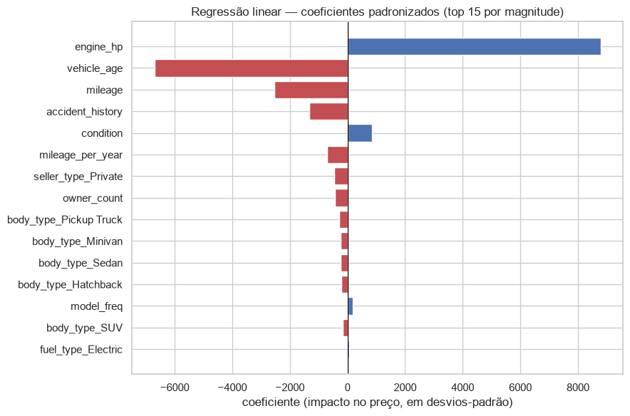

```python
# Evidência visual: top features por magnitude do coeficiente padronizado.
top = res.head(15).iloc[::-1]
fig, ax = plt.subplots(figsize=(9, 6))
colors = ["#C44E52" if c < 0 else "#4C72B0" for c in top["coef"]]
ax.barh(top.index, top["coef"], color=colors)
ax.set_title("Regressão linear — coeficientes padronizados (top 15 por magnitude)")
ax.set_xlabel("coeficiente (impacto no preço, em desvios-padrão)")
ax.axvline(0, color="black", linewidth=0.8)
plt.tight_layout()
plt.show()
```

## 3. Agrupamento com K-means (Tarefa 5.2.2)

Agrupamos os veículos pelas suas **características** (usamos `X_scaled`). O preço **não** entra como feature de agrupamento, para que os grupos reflitam similaridade de atributos do veículo — e possamos depois observar como o preço se distribui em cada grupo.

Escolha de `k`: combinamos o **método do cotovelo** (inércia) com o **coeficiente de silhueta** (calculado em subamostra, pois é O(n²)).

```python
# X_scaled já exclui o preço (price é o alvo, ficou em y).
X_clust = X_scaled

ks = range(2, 9)
inertias, silhouettes = [], []

# Para a busca de k, treinamos o MiniBatchKMeans em uma subamostra representativa
# de 100.000 linhas, e calculamos a silhueta em 2.000 pontos. Isso evita travamentos (OOM).
search_idx = np.random.choice(len(X_clust), size=min(100_000, len(X_clust)), replace=False)
X_search = X_clust.iloc[search_idx]

for k in ks:
    km = MiniBatchKMeans(n_clusters=k, random_state=RANDOM_STATE, n_init=5, batch_size=4096)
    labels_search = km.fit_predict(X_search)
    inertias.append(km.inertia_)

    # Subamostra para o cálculo da silhueta (métrica O(n^2) em relação ao número de pontos)
    sil_idx = np.random.choice(len(X_search), size=min(2_000, len(X_search)), replace=False)
    silhouettes.append(silhouette_score(X_search.iloc[sil_idx], labels_search[sil_idx]))
    print(f"k={k}: inertia={km.inertia_:,.0f} | silhouette={silhouettes[-1]:.4f}")
```

```
k=2: inertia=3,380,488 | silhouette=0.0620
```

```
k=3: inertia=3,302,092 | silhouette=0.0422
```

```
k=4: inertia=3,229,590 | silhouette=0.0327
```

```
k=5: inertia=3,196,026 | silhouette=0.0356
```

```
k=6: inertia=3,118,367 | silhouette=0.0404
```

```
k=7: inertia=3,084,226 | silhouette=0.0384
```

```
k=8: inertia=2,968,270 | silhouette=0.0531
```

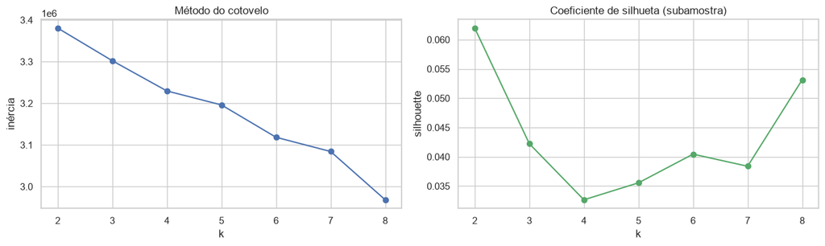

```python
fig, axes = plt.subplots(1, 2, figsize=(13, 4))
axes[0].plot(list(ks), inertias, "o-", color="#4C72B0")
axes[0].set_title("Método do cotovelo")
axes[0].set_xlabel("k"); axes[0].set_ylabel("inércia")
axes[1].plot(list(ks), silhouettes, "o-", color="#55A868")
axes[1].set_title("Coeficiente de silhueta (subamostra)")
axes[1].set_xlabel("k"); axes[1].set_ylabel("silhouette")
plt.tight_layout()
plt.show()
```

```python
K = 4
kmeans = MiniBatchKMeans(n_clusters=K, random_state=RANDOM_STATE, n_init=10, batch_size=4096)
# Alternativa (mais lenta em 1M, porém K-means clássico):
# kmeans = KMeans(n_clusters=K, random_state=RANDOM_STATE, n_init=10)

cluster_labels = kmeans.fit_predict(X_clust)
df_work = df_work.copy()
df_work["cluster"] = cluster_labels

print("Tamanho de cada cluster:")
print(df_work["cluster"].value_counts().sort_index())
```

```
Tamanho de cada cluster:
cluster
0    239425
1    235664
2    268791
3    256120
Name: count, dtype: int64
```

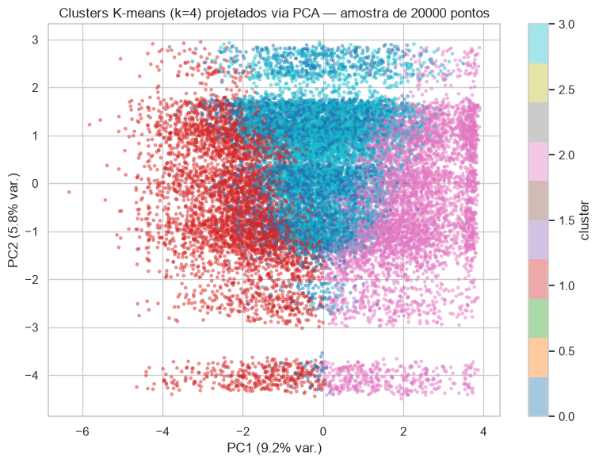

```python
# Visualização 2D via PCA (modelo treinado e projetado em uma subamostra de 20k p/ leveza e velocidade).
plot_idx = np.random.choice(len(X_clust), size=min(20_000, len(X_clust)), replace=False)
X_plot = X_clust.iloc[plot_idx]

pca = PCA(n_components=2, random_state=RANDOM_STATE)
coords = pca.fit_transform(X_plot)

fig, ax = plt.subplots(figsize=(8, 6))
sc = ax.scatter(coords[:, 0], coords[:, 1],
                c=cluster_labels[plot_idx], cmap="tab10", s=6, alpha=0.4)
ax.set_title(f"Clusters K-means (k={K}) projetados via PCA — amostra de {len(plot_idx)} pontos")
ax.set_xlabel(f"PC1 ({pca.explained_variance_ratio_[0]*100:.1f}% var.)")
ax.set_ylabel(f"PC2 ({pca.explained_variance_ratio_[1]*100:.1f}% var.)")
plt.colorbar(sc, label="cluster")
plt.tight_layout()
plt.show()
```

### 3.1 Análise de um dos grupos

```python
# Perfil numérico médio de cada cluster (nas variáveis originais + preço).
profile_cols = NUMERIC_COLS + ["condition", "accident_history", "price"]
profile = df_work.copy()
profile[ORDINAL_COLS] = ord_enc.transform(profile[ORDINAL_COLS])
cluster_profile = profile.groupby("cluster")[profile_cols].mean().round(2)
cluster_profile
```

| cluster | year | mileage | engine_hp | owner_count | vehicle_age | mileage_per_year | brand_popularity | condition | accident_history | price |
| --- | --- | --- | --- | --- | --- | --- | --- | --- | --- | --- |
| 0 | 2016.85 | 115205.88 | 263.66 | 3.99 | 8.15 | 14621.98 | 0.04 | 1.30 | 0.34 | 21089.05 |
| 1 | 2013.08 | 197911.74 | 224.32 | 4.63 | 11.92 | 16978.40 | 0.04 | 1.30 | 0.28 | 8743.20 |
| 2 | 2021.69 | 44133.65 | 230.29 | 1.84 | 3.46 | 12326.28 | 0.04 | 1.30 | 0.29 | 30764.95 |
| 3 | 2017.59 | 103754.33 | 225.57 | 3.67 | 7.41 | 14545.59 | 0.04 | 1.29 | 0.29 | 19327.88 |

```python
# Escolhemos um cluster para detalhar (o de maior preço médio).
target_cluster = int(cluster_profile["price"].idxmax())
grp = df_work[df_work["cluster"] == target_cluster]
print(f"Cluster analisado: {target_cluster} | nº de veículos: {len(grp):,}")
print(f"Preço médio: US$ {grp['price'].mean():,.0f}  (geral: US$ {df_work['price'].mean():,.0f})")

print("\nCategorias predominantes neste grupo:")
for c in ["make", "body_type", "fuel_type", "drivetrain", "condition", "transmission"]:
    top_val = grp[c].value_counts(normalize=True).head(3)
    print(f"  {c}: " + ", ".join(f"{k} ({v*100:.0f}%)" for k, v in top_val.items()))
```

```
Cluster analisado: 2 | nº de veículos: 268,791
Preço médio: US$ 30,765  (geral: US$ 20,329)

Categorias predominantes neste grupo:
  make: Hyundai (7%), Toyota (6%), GMC (6%)
  body_type: SUV (43%), Sedan (24%), Pickup Truck (16%)
```

```
  fuel_type: Gasoline (35%), Diesel (33%), Electric (32%)
  drivetrain: AWD (35%), RWD (34%), FWD (31%)
  condition: Good (50%), Excellent (40%), Fair (10%)
```

```
  transmission: Manual (50%), Automatic (50%)
```

## 4. Vizinhos mais próximos com K-NN (Tarefa 5.2.3)

Escolhemos um veículo e usamos `NearestNeighbors` (distância euclidiana no mesmo espaço padronizado `X_scaled`) para encontrar os **5 mais parecidos**. Depois verificamos se esses vizinhos caem no **mesmo cluster** do K-means — uma checagem de consistência entre os dois métodos.

```python
nn = NearestNeighbors(n_neighbors=6, algorithm="brute", metric="euclidean")
nn.fit(X_clust.to_numpy())

# Veículo de referência (índice fixo para reprodutibilidade).
query_pos = 0
distances, indices = nn.kneighbors(X_clust.iloc[[query_pos]].to_numpy())

neighbor_pos = indices[0]              # inclui o próprio veículo na posição 0
neighbor_dist = distances[0]

show_cols = ["make", "model", "year", "mileage", "engine_hp", "fuel_type",
             "drivetrain", "body_type", "condition", "price", "cluster"]
result = df_work.iloc[neighbor_pos][show_cols].copy()
result.insert(0, "distancia", neighbor_dist.round(3))
result.insert(0, "papel", ["REFERÊNCIA"] + [f"vizinho {i}" for i in range(1, 6)])
result.reset_index(drop=True)
```

|  | papel | distancia | make | model | year | mileage | engine_hp | fuel_type | drivetrain | body_type | condition | price | cluster |
| --- | --- | --- | --- | --- | --- | --- | --- | --- | --- | --- | --- | --- | --- |
| 0 | REFERÊNCIA | 0.000 | Volkswagen | Jetta | 2016 | 183903 | 173 | Electric | RWD | Sedan | Excellent | 7208.52 | 3 |
| 1 | vizinho 1 | 1.373 | Honda | CR-V | 2016 | 124782 | 172 | Electric | RWD | Sedan | Excellent | 9101.85 | 3 |
| 2 | vizinho 2 | 1.486 | Lexus | IS | 2014 | 223281 | 225 | Electric | RWD | Sedan | Excellent | 11135.05 | 1 |
| 3 | vizinho 3 | 1.617 | Honda | CR-V | 2014 | 139032 | 164 | Electric | RWD | Sedan | Excellent | 6838.35 | 3 |
| 4 | vizinho 4 | 1.641 | Mazda | CX-5 | 2017 | 158085 | 161 | Electric | RWD | Sedan | Excellent | 8992.23 | 3 |
| 5 | vizinho 5 | 2.158 | Nissan | Sentra | 2020 | 117335 | 158 | Electric | RWD | Sedan | Excellent | 13508.78 | 3 |

```python
ref_cluster = int(df_work.iloc[query_pos]["cluster"])
neigh_clusters = df_work.iloc[neighbor_pos[1:]]["cluster"].tolist()
same = sum(c == ref_cluster for c in neigh_clusters)

print(f"Cluster do veículo de referência: {ref_cluster}")
print(f"Clusters dos 5 vizinhos: {neigh_clusters}")
print(f"Vizinhos no mesmo cluster da referência: {same} de 5")
```

```
Cluster do veículo de referência: 3
Clusters dos 5 vizinhos: [3, 1, 3, 3, 3]
Vizinhos no mesmo cluster da referência: 4 de 5
```